# Active Power Analysis and Prediction using LSTM

##### - Name : Vikram Pande

##### - Unity ID: vspande

##### - Student ID: 200473855

## INTRODUCTION

Households use energies for different purposes. It is a very common thing and needs to be analysed on daily to yearly basis to get the insights of average energy consumption of a particular household and combined consumptions of many. The total energy consumed by a household other than sub meter appliances is Global Active Power. The power which bounces back and forth without any usage or leakage is Global Reactive Power. There is power calculated from the unit meteres ( commonly 3 because of three phase ). It is important to know how much energy the appliances actually require. This project is aiming to predict the overall active power consumption of household.

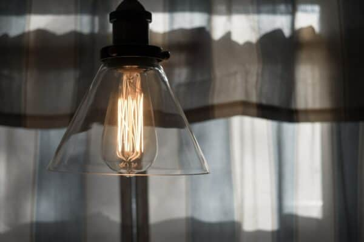

## Problem Statement

This project is mainly focusing on predicition and comparison the Active Energy usage of a particular Household for various time instances such as monthly, weekly, daily and hourly. The plan is to compare active power changes over different time instances, compare and estimate the model performance.

This task will be a Time-Series Analysis type of task. There are multiple state-of-art TimeSeries models are available such as ARIMA, SARIMA, Single Exponential etc. The stat-of-art Deep Learning RNN based LSTM model is also pretty common while solving Time Series because of accurate results.

### Dataset

The dataset "Individual household electric power consumption Data Set" used for the analysis and prediction purpose is from UCI Machine Learning repo which can be found [here](https://archive.ics.uci.edu/ml/datasets/Individual+household+electric+power+consumption#).

The dataset desribes the power consumption of a particular house in France in the period of December 2006 to November 2010, overall 4 years. The reason to chose this dataset is that it has 2075259 instances of data measured in 4 years with timestamp which is perfect to learn Time Series Problems as beginner.

The dataset mainly talks about global active power, global reactive power , intensity, voltage and readings from three submeters. The Active Power is the power consumed by equipment directly ignoring values from sub-meters. From the above parameters, we can calculate Active Power by the formula:

Active Power = (Global Active Power) *(1000/60) - (summation of submeters) Active Power = (global_active_power* 1000/60 - sub_metering_1 - sub_metering_2 - sub_metering_3) [formula](https://archive.ics.uci.edu/ml/datasets/Individual+household+electric+power+consumption)

## Methodology

The project aims to predict the values of active power with the help of given timestamps. The project is mainly divided into three parts such as data preparation, visualisations and model building.

### Data Preparation

- For data preparation, the whole dataset is divided into subsets of data grouped by the average values of hour, days, weeks, months and years. Data preprocessing is done by manipulating null values and some columns.

### Data Visualization

- The trends of Active Power are visualised based on different time instances before training.
- The trends of Active power are visualised after training the model and compared before-after results by overlaying graph plot structure.
- Loss of the model is visualised which should be decreasing over the epochs.

### Modeling

##### Why LSTM?

- This is the main part of the project where comparison over time instances is done. There are many techniques to tackle Time Series problems such as AR, VAR, ARIMA, SARIMA, SES etc. However, for this task a powerful deep learning model LSTM ( Long-Short-Term-Memory ) is used because it is a sequential model which helps in predicting future data with better accuracy and decision making. LSTM is capable to capture underlying patterns for both long term as well as short term time instances. It is capable of taking input of different lengths which is better for Time Series. These are some main reasons to use LSTM architecture.
- There are type of LSTM such as Single/Uni Variate LSTM, BiVariate LSTM and multivariate LSTM. For this project Single/Univariate LSTM is used.

##### A little bit about LSTM:

- LSTM is a Recurrent Neural Network which is able to remember values over arbitrary instances. LSTM has feedback connections. The LSTM architecture aims to provide a short-term memory for RNN that can last thousands of timesteps, thus long short-term memory. A common LSTM unit is composed of a cell, an input gate, an output gate and a forget gate. The cell remembers values over arbitrary time intervals and the three gates regulate the flow of information into and out of the cell. LSTM deals with Vanishing Gradient Problem. Hence, LSTM is well suited for continuous data problems like Time Series. *source:* [Wikipedia](https://en.wikipedia.org/wiki/Long_short-term_memory)

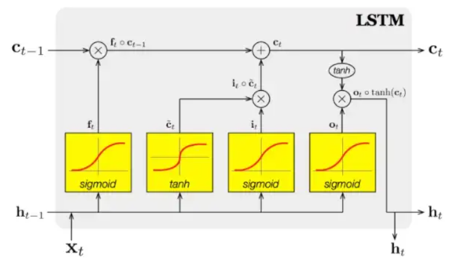

### Project Structure

This project is divided into parts as follows:

- Importing Libraries.
- Data Preprocessing - Missing Values, Feature Engineering.
- Getting and Storing datasets.
- Correlation.
- Hypothesis Testing.
- Visualization.
- LSTM Forecasting - Monthly, Weekly, Daily, Hourly.
- Results.
- Conclusion.
- References

### 1. Importing Libraries

```python
# Matrix, Dataframe operations and Metrics.
import pandas as pd
import numpy as np
import matplotlib.pyplot as plt
from datetime import datetime
from scipy import stats
from sklearn.metrics import mean_squared_error
from sklearn.metrics import r2_score

# MAPE calculation
def mape(a, f):
    return np.mean(np.abs((a - f) / a))

# For LSTM
import math
from sklearn.preprocessing import MinMaxScaler
import torch
import torch.nn as nn
from torch.autograd import Variable
from sklearn.metrics import mean_squared_error
torch.manual_seed(1)

# To filter warnings
import warnings
warnings.filterwarnings('ignore')
```

```python
# Reading the Dataset
consumption_data = pd.read_csv('data\household_power_consumption.txt', sep=';',
                parse_dates={'dt' : ['Date', 'Time']}, infer_datetime_format=True, na_values=['nan','?'], index_col='dt')
```

```python
# Dataset Shape
consumption_data.shape
```

```
(2075259, 7)
```

```python
# First 5 instances
consumption_data.head(5)
```

| dt | Global_active_power | Global_reactive_power | Voltage | Global_intensity | Sub_metering_1 | Sub_metering_2 | Sub_metering_3 |
| --- | --- | --- | --- | --- | --- | --- | --- |
| 2006-12-16 17:24:00 | 4.216 | 0.418 | 234.84 | 18.4 | 0.0 | 1.0 | 17.0 |
| 2006-12-16 17:25:00 | 5.360 | 0.436 | 233.63 | 23.0 | 0.0 | 1.0 | 16.0 |
| 2006-12-16 17:26:00 | 5.374 | 0.498 | 233.29 | 23.0 | 0.0 | 2.0 | 17.0 |
| 2006-12-16 17:27:00 | 5.388 | 0.502 | 233.74 | 23.0 | 0.0 | 1.0 | 17.0 |
| 2006-12-16 17:28:00 | 3.666 | 0.528 | 235.68 | 15.8 | 0.0 | 1.0 | 17.0 |

Checking for Missing Data

```python
# Missing data handling
null_count = consumption_data.isnull().sum()
null_count
```

```
Global_active_power      25979
Global_reactive_power    25979
Voltage                  25979
Global_intensity         25979
Sub_metering_1           25979
Sub_metering_2           25979
Sub_metering_3           25979
dtype: int64
```

```python
# Finding the Percentage of missing values to see if we can drop them directly or not
null_percent = (null_count/len(consumption_data))*100
null_percent
```

```
Global_active_power      1.251844
Global_reactive_power    1.251844
Voltage                  1.251844
Global_intensity         1.251844
Sub_metering_1           1.251844
Sub_metering_2           1.251844
Sub_metering_3           1.251844
dtype: float64
```

It is observed that there is almost 1.251844 % of the missing data out of total data. Since this is a Time-Series type of the datase, the missing values could be filled with forward or backward values as the data is continuous assuming not much difference in between values.

```python
# Backfilling the missing values
consumption_data.bfill(axis=0,inplace=True)
```

```python
# Finding Active Power
gap = (consumption_data['Global_active_power']*1000/60)
sub_meters = consumption_data['Sub_metering_1'] + consumption_data['Sub_metering_2'] + consumption_data['Sub_metering_3']
consumption_data['active_power'] = gap - sub_meters
consumption_data.head()
```

| dt | Global_active_power | Global_reactive_power | Voltage | Global_intensity | Sub_metering_1 | Sub_metering_2 | Sub_metering_3 | active_power |
| --- | --- | --- | --- | --- | --- | --- | --- | --- |
| 2006-12-16 17:24:00 | 4.216 | 0.418 | 234.84 | 18.4 | 0.0 | 1.0 | 17.0 | 52.266667 |
| 2006-12-16 17:25:00 | 5.360 | 0.436 | 233.63 | 23.0 | 0.0 | 1.0 | 16.0 | 72.333333 |
| 2006-12-16 17:26:00 | 5.374 | 0.498 | 233.29 | 23.0 | 0.0 | 2.0 | 17.0 | 70.566667 |
| 2006-12-16 17:27:00 | 5.388 | 0.502 | 233.74 | 23.0 | 0.0 | 1.0 | 17.0 | 71.800000 |
| 2006-12-16 17:28:00 | 3.666 | 0.528 | 235.68 | 15.8 | 0.0 | 1.0 | 17.0 | 43.100000 |

```python
# Getting datetime together
consumption_data['date'] = (consumption_data.index.date).astype(str)
consumption_data['time'] = (consumption_data.index.time).astype(str)
consumption_data.head(5)
```

| dt | Global_active_power | Global_reactive_power | Voltage | Global_intensity | Sub_metering_1 | Sub_metering_2 | Sub_metering_3 | active_power | date | time |
| --- | --- | --- | --- | --- | --- | --- | --- | --- | --- | --- |
| 2006-12-16 17:24:00 | 4.216 | 0.418 | 234.84 | 18.4 | 0.0 | 1.0 | 17.0 | 52.266667 | 2006-12-16 | 17:24:00 |
| 2006-12-16 17:25:00 | 5.360 | 0.436 | 233.63 | 23.0 | 0.0 | 1.0 | 16.0 | 72.333333 | 2006-12-16 | 17:25:00 |
| 2006-12-16 17:26:00 | 5.374 | 0.498 | 233.29 | 23.0 | 0.0 | 2.0 | 17.0 | 70.566667 | 2006-12-16 | 17:26:00 |
| 2006-12-16 17:27:00 | 5.388 | 0.502 | 233.74 | 23.0 | 0.0 | 1.0 | 17.0 | 71.800000 | 2006-12-16 | 17:27:00 |
| 2006-12-16 17:28:00 | 3.666 | 0.528 | 235.68 | 15.8 | 0.0 | 1.0 | 17.0 | 43.100000 | 2006-12-16 | 17:28:00 |

```python
consumption_data['datetime'] = consumption_data['date']+";"+consumption_data['time']
consumption_data['datetime'] = pd.to_datetime(consumption_data['datetime'],format="%Y-%m-%d;%H:%M:%S")
consumption_data.head(5)
```

| dt | Global_active_power | Global_reactive_power | Voltage | Global_intensity | Sub_metering_1 | Sub_metering_2 | Sub_metering_3 | active_power | date | time | datetime |
| --- | --- | --- | --- | --- | --- | --- | --- | --- | --- | --- | --- |
| 2006-12-16 17:24:00 | 4.216 | 0.418 | 234.84 | 18.4 | 0.0 | 1.0 | 17.0 | 52.266667 | 2006-12-16 | 17:24:00 | 2006-12-16 17:24:00 |
| 2006-12-16 17:25:00 | 5.360 | 0.436 | 233.63 | 23.0 | 0.0 | 1.0 | 16.0 | 72.333333 | 2006-12-16 | 17:25:00 | 2006-12-16 17:25:00 |
| 2006-12-16 17:26:00 | 5.374 | 0.498 | 233.29 | 23.0 | 0.0 | 2.0 | 17.0 | 70.566667 | 2006-12-16 | 17:26:00 | 2006-12-16 17:26:00 |
| 2006-12-16 17:27:00 | 5.388 | 0.502 | 233.74 | 23.0 | 0.0 | 1.0 | 17.0 | 71.800000 | 2006-12-16 | 17:27:00 | 2006-12-16 17:27:00 |
| 2006-12-16 17:28:00 | 3.666 | 0.528 | 235.68 | 15.8 | 0.0 | 1.0 | 17.0 | 43.100000 | 2006-12-16 | 17:28:00 | 2006-12-16 17:28:00 |

```python
# Dropping unnecessary columns
consumption_data = consumption_data.drop(['date', 'time'],axis = 1).sort_values(by=['datetime'])
print(consumption_data.shape)
consumption_data.head(5)
```

```
(2075259, 9)
```

| dt | Global_active_power | Global_reactive_power | Voltage | Global_intensity | Sub_metering_1 | Sub_metering_2 | Sub_metering_3 | active_power | datetime |
| --- | --- | --- | --- | --- | --- | --- | --- | --- | --- |
| 2006-12-16 17:24:00 | 4.216 | 0.418 | 234.84 | 18.4 | 0.0 | 1.0 | 17.0 | 52.266667 | 2006-12-16 17:24:00 |
| 2006-12-16 17:25:00 | 5.360 | 0.436 | 233.63 | 23.0 | 0.0 | 1.0 | 16.0 | 72.333333 | 2006-12-16 17:25:00 |
| 2006-12-16 17:26:00 | 5.374 | 0.498 | 233.29 | 23.0 | 0.0 | 2.0 | 17.0 | 70.566667 | 2006-12-16 17:26:00 |
| 2006-12-16 17:27:00 | 5.388 | 0.502 | 233.74 | 23.0 | 0.0 | 1.0 | 17.0 | 71.800000 | 2006-12-16 17:27:00 |
| 2006-12-16 17:28:00 | 3.666 | 0.528 | 235.68 | 15.8 | 0.0 | 1.0 | 17.0 | 43.100000 | 2006-12-16 17:28:00 |

```python
# Getting Statistics of the Data
consumption_data.describe()
```

|  | Global_active_power | Global_reactive_power | Voltage | Global_intensity | Sub_metering_1 | Sub_metering_2 | Sub_metering_3 | active_power |
| --- | --- | --- | --- | --- | --- | --- | --- | --- |
| count | 2.075259e+06 | 2.075259e+06 | 2.075259e+06 | 2.075259e+06 | 2.075259e+06 | 2.075259e+06 | 2.075259e+06 | 2.075259e+06 |
| mean | 1.094391e+00 | 1.239705e-01 | 2.408240e+02 | 4.638736e+00 | 1.107975e+00 | 1.290500e+00 | 6.468201e+00 | 9.373169e+00 |
| std | 1.054990e+00 | 1.126516e-01 | 3.251230e+00 | 4.434058e+00 | 6.115943e+00 | 5.787128e+00 | 8.455677e+00 | 9.590144e+00 |
| min | 7.600000e-02 | 0.000000e+00 | 2.232000e+02 | 2.000000e-01 | 0.000000e+00 | 0.000000e+00 | 0.000000e+00 | -2.400000e+00 |
| 25% | 3.100000e-01 | 4.800000e-02 | 2.389600e+02 | 1.400000e+00 | 0.000000e+00 | 0.000000e+00 | 0.000000e+00 | 3.833333e+00 |
| 50% | 6.200000e-01 | 1.000000e-01 | 2.410100e+02 | 2.800000e+00 | 0.000000e+00 | 0.000000e+00 | 1.000000e+00 | 5.533333e+00 |
| 75% | 1.536000e+00 | 1.960000e-01 | 2.429000e+02 | 6.400000e+00 | 0.000000e+00 | 1.000000e+00 | 1.700000e+01 | 1.053333e+01 |
| max | 1.112200e+01 | 1.390000e+00 | 2.541500e+02 | 4.840000e+01 | 8.800000e+01 | 8.000000e+01 | 3.100000e+01 | 1.248333e+02 |

### 2. Getting seperate Datasets for seperate predictions

```python
# Hourly Data
hourly_data = consumption_data.resample('h').mean()
print(hourly_data.shape)
hourly_data.to_csv('data/hourly_data.csv')
hourly_data.head()
```

```
(34589, 8)
```

| dt | Global_active_power | Global_reactive_power | Voltage | Global_intensity | Sub_metering_1 | Sub_metering_2 | Sub_metering_3 | active_power |
| --- | --- | --- | --- | --- | --- | --- | --- | --- |
| 2006-12-16 17:00:00 | 4.222889 | 0.229000 | 234.643889 | 18.100000 | 0.0 | 0.527778 | 16.861111 | 52.992593 |
| 2006-12-16 18:00:00 | 3.632200 | 0.080033 | 234.580167 | 15.600000 | 0.0 | 6.716667 | 16.866667 | 36.953333 |
| 2006-12-16 19:00:00 | 3.400233 | 0.085233 | 233.232500 | 14.503333 | 0.0 | 1.433333 | 16.683333 | 38.553889 |
| 2006-12-16 20:00:00 | 3.268567 | 0.075100 | 234.071500 | 13.916667 | 0.0 | 0.000000 | 16.783333 | 37.692778 |
| 2006-12-16 21:00:00 | 3.056467 | 0.076667 | 237.158667 | 13.046667 | 0.0 | 0.416667 | 17.216667 | 33.307778 |

```python
# Daily Data
daily_data = consumption_data.resample('d').mean()
print(daily_data.shape)
daily_data.to_csv('data/daily_data.csv')
daily_data.head()
```

```
(1442, 8)
```

| dt | Global_active_power | Global_reactive_power | Voltage | Global_intensity | Sub_metering_1 | Sub_metering_2 | Sub_metering_3 | active_power |
| --- | --- | --- | --- | --- | --- | --- | --- | --- |
| 2006-12-16 | 3.053475 | 0.088187 | 236.243763 | 13.082828 | 0.000000 | 1.378788 | 12.439394 | 37.073064 |
| 2006-12-17 | 2.354486 | 0.156949 | 240.087028 | 9.999028 | 1.411806 | 2.907639 | 9.264583 | 25.657407 |
| 2006-12-18 | 1.530435 | 0.112356 | 241.231694 | 6.421667 | 0.738194 | 1.820139 | 9.734722 | 13.214190 |
| 2006-12-19 | 1.157079 | 0.104821 | 241.999313 | 4.926389 | 0.582639 | 5.279167 | 4.303472 | 9.119375 |
| 2006-12-20 | 1.545658 | 0.111804 | 242.308063 | 6.467361 | 0.000000 | 1.838889 | 9.765972 | 14.156111 |

```python
# Weekly Data
weekly_data = consumption_data.resample('w').mean()
print(weekly_data.shape)
weekly_data.to_csv('data/weekly_data.csv')
weekly_data.head()
```

```
(207, 8)
```

| dt | Global_active_power | Global_reactive_power | Voltage | Global_intensity | Sub_metering_1 | Sub_metering_2 | Sub_metering_3 | active_power |
| --- | --- | --- | --- | --- | --- | --- | --- | --- |
| 2006-12-17 | 2.505248 | 0.142118 | 239.258088 | 10.664161 | 1.107298 | 2.577887 | 9.949346 | 28.119608 |
| 2006-12-24 | 1.733891 | 0.116684 | 241.369808 | 7.340714 | 1.110119 | 2.118155 | 7.683234 | 17.986673 |
| 2006-12-31 | 1.959340 | 0.144156 | 241.909223 | 8.242123 | 1.419742 | 2.250397 | 6.673710 | 22.311822 |
| 2007-01-07 | 1.484233 | 0.133825 | 240.921636 | 6.262123 | 0.581052 | 1.745933 | 5.376290 | 17.033942 |
| 2007-01-14 | 1.605113 | 0.157786 | 240.269575 | 6.831825 | 1.331349 | 1.883829 | 8.271131 | 15.265572 |

```python
# Monthly Data
monthly_data = consumption_data.resample('m').mean()
print(monthly_data.shape)
monthly_data.to_csv('data/monthly_data.csv')
monthly_data.head()
```

```
(48, 8)
```

| dt | Global_active_power | Global_reactive_power | Voltage | Global_intensity | Sub_metering_1 | Sub_metering_2 | Sub_metering_3 | active_power |
| --- | --- | --- | --- | --- | --- | --- | --- | --- |
| 2006-12-31 | 1.901591 | 0.131396 | 241.440738 | 8.031206 | 1.251773 | 2.217130 | 7.409756 | 20.814531 |
| 2007-01-31 | 1.546088 | 0.132681 | 240.904779 | 6.547151 | 1.264180 | 1.775874 | 7.383737 | 15.344341 |
| 2007-02-28 | 1.401257 | 0.113638 | 240.519176 | 5.915298 | 1.180159 | 1.604067 | 6.704067 | 13.865988 |
| 2007-03-31 | 1.318613 | 0.114752 | 240.513507 | 5.572921 | 1.361313 | 2.346819 | 6.504503 | 11.764243 |
| 2007-04-30 | 0.834380 | 0.115264 | 238.983772 | 3.582157 | 0.974028 | 0.889282 | 4.386644 | 7.656374 |

```python
# Yearly Data
yearly_data = consumption_data.resample('y').mean()
print(yearly_data.shape)
monthly_data.to_csv('data/yearly_data.csv')
yearly_data.head()
```

```
(5, 8)
```

| dt | Global_active_power | Global_reactive_power | Voltage | Global_intensity | Sub_metering_1 | Sub_metering_2 | Sub_metering_3 | active_power |
| --- | --- | --- | --- | --- | --- | --- | --- | --- |
| 2006-12-31 | 1.901591 | 0.131396 | 241.440738 | 8.031206 | 1.251773 | 2.217130 | 7.409756 | 20.814531 |
| 2007-12-31 | 1.110842 | 0.117115 | 239.349393 | 4.738260 | 1.222508 | 1.626284 | 5.753465 | 9.911773 |
| 2008-12-31 | 1.072340 | 0.117162 | 240.625976 | 4.552993 | 1.109631 | 1.256056 | 6.036735 | 9.469916 |
| 2009-12-31 | 1.084109 | 0.131901 | 241.872882 | 4.577482 | 1.127673 | 1.126663 | 6.924760 | 8.889395 |
| 2010-12-31 | 1.074651 | 0.129992 | 241.486036 | 4.534436 | 0.950956 | 1.095553 | 7.188980 | 8.675368 |

### 3. Correlation between Variables

```python
# Plotting Correlation
corr_whole = consumption_data.corr()
corr_whole.style.background_gradient(cmap='coolwarm')
```

|  | Global_active_power | Global_reactive_power | Voltage | Global_intensity | Sub_metering_1 | Sub_metering_2 | Sub_metering_3 | active_power |
| --- | --- | --- | --- | --- | --- | --- | --- | --- |
| Global_active_power | 1.000000 | 0.242494 | -0.398128 | 0.998894 | 0.481871 | 0.431681 | 0.639708 | 0.701629 |
| Global_reactive_power | 0.242494 | 1.000000 | -0.102553 | 0.261462 | 0.121994 | 0.139146 | 0.084983 | 0.207907 |
| Voltage | -0.398128 | -0.102553 | 1.000000 | -0.409587 | -0.193148 | -0.163771 | -0.272638 | -0.267564 |
| Global_intensity | 0.998894 | 0.261462 | -0.409587 | 1.000000 | 0.486846 | 0.437537 | 0.627841 | 0.703358 |
| Sub_metering_1 | 0.481871 | 0.121994 | -0.193148 | 0.486846 | 1.000000 | 0.054967 | 0.101483 | 0.123113 |
| Sub_metering_2 | 0.431681 | 0.139146 | -0.163771 | 0.437537 | 0.054967 | 1.000000 | 0.079014 | 0.083305 |
| Sub_metering_3 | 0.639708 | 0.084983 | -0.272638 | 0.627841 | 0.101483 | 0.079014 | 1.000000 | 0.178776 |
| active_power | 0.701629 | 0.207907 | -0.267564 | 0.703358 | 0.123113 | 0.083305 | 0.178776 | 1.000000 |

### 4. Hypothesis Testing

Testing the hypothesis that the mean of Daily Active Power Hourly is 9 at the significance level 5%.

- Assume, H0: Mean is 9
- H1: otherwise.

```python
# Filtering Daily Data
consumption_data['day'] = consumption_data.index.day
```

```python
hourly_activepower_mean = consumption_data.groupby(['day'])['active_power'].mean().reset_index()
# hourly_activepower_mean
```

```python
res = stats.ttest_1samp(hourly_activepower_mean, 9)
res
```

```
Ttest_1sampResult(statistic=array([4.28660705, 5.96134236]), pvalue=array([1.72774887e-04, 1.55345442e-06]))
```

```python
for pvalue in res.pvalue:
    if pvalue >= 0.05:
        print('Fail to reject H0')
    else:
        print('Reject H0')
```

```
Reject H0
Reject H0
```

### 5. Visualizations

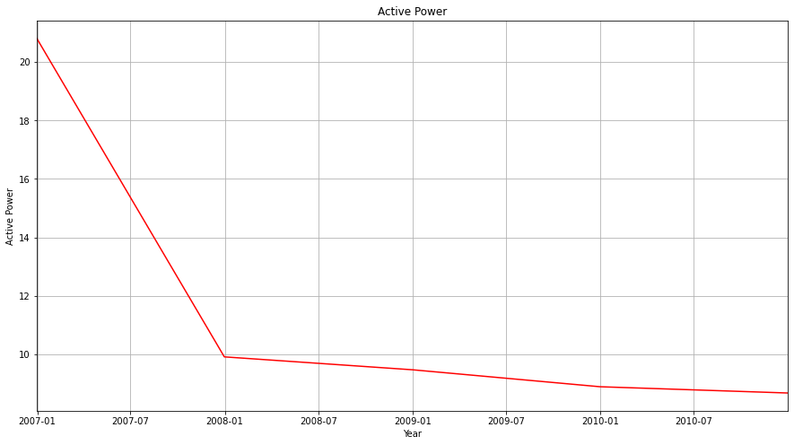

```python
# Global Active Power Yearly
fig = plt.figure(figsize = (15,8))
plt.title('Active Power')
plt.plot(yearly_data['active_power'], color='r')
plt.xlabel('Year')
plt.ylabel('Active Power')
figPath = 'figures/'
plt.grid(True)
plt.autoscale(axis='x',tight=True)
plt.show()
fig.savefig(figPath + 'energy_consumption_yearly.png', dpi = 300)
```

Active Power has decreased over the period of 4 years.

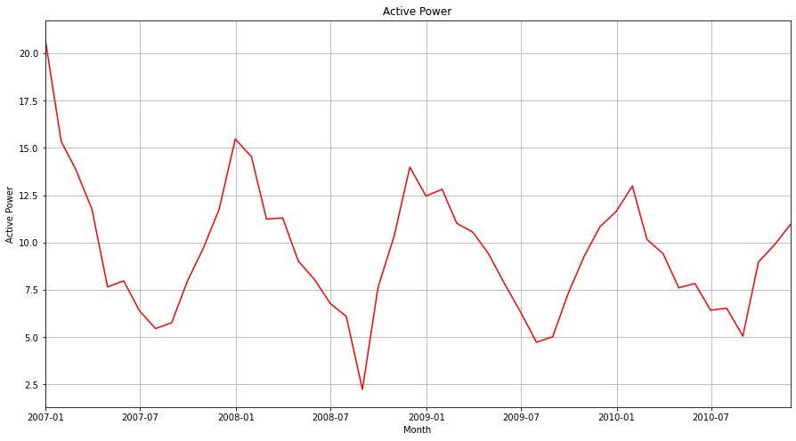

```python
# Global Active Power Monthly
fig = plt.figure(figsize = (15,8))
plt.title('Active Power')
plt.plot(monthly_data['active_power'], color='r')
plt.xlabel('Month')
plt.ylabel('Active Power')
figPath = 'figures/'
plt.grid(True)
plt.autoscale(axis='x',tight=True)
plt.show()
fig.savefig(figPath + 'energy_consumption_monthly.png', dpi = 300)
```

This type of distribution is called as non-stationary data. That means, we can conclude that monthly active power is fluctuating.

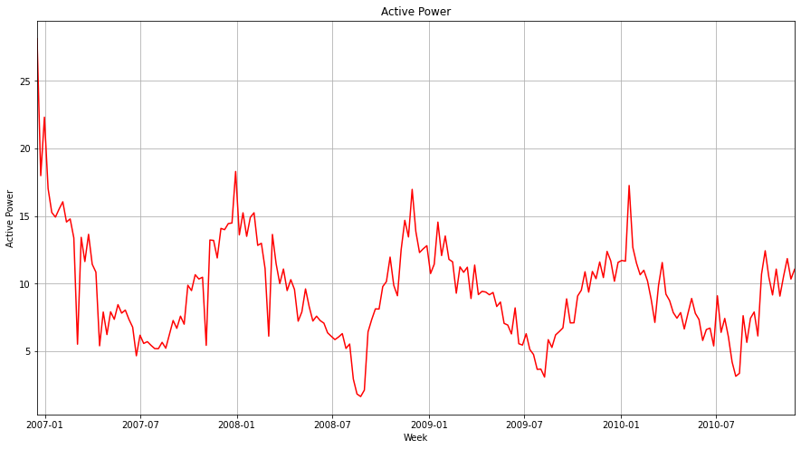

```python
# Global Active Power Weekly
fig = plt.figure(figsize = (15,8))
plt.title('Active Power')
plt.plot(weekly_data['active_power'], color='r')
plt.xlabel('Week')
plt.ylabel('Active Power')
figPath = 'figures/'
plt.grid(True)
plt.autoscale(axis='x',tight=True)
plt.show()
fig.savefig(figPath + 'energy_consumption_weekly.png', dpi = 300)
```

Active Power is non statoinary over the weeks.

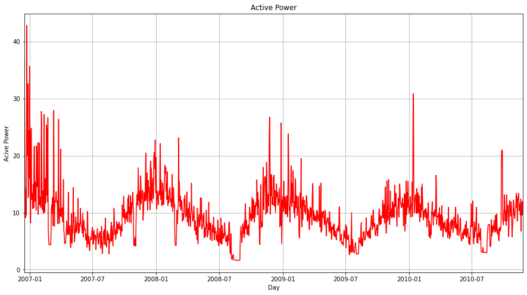

```python
# Global Active Power Daily
fig = plt.figure(figsize = (15,8))
plt.title('Active Power')
plt.plot(daily_data['active_power'], color='r')
plt.xlabel('Day')
plt.ylabel('Acive Power')
figPath = 'figures/'
plt.grid(True)
plt.autoscale(axis='x',tight=True)
plt.show()
fig.savefig(figPath + 'energy_consumption_daily.png', dpi = 300)
```

Active Power is fluctuating on a daily basis more than weekly basis.

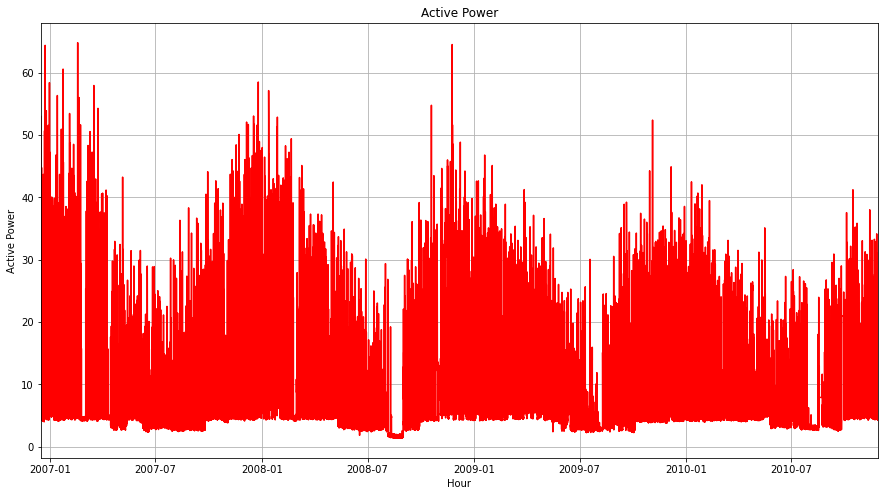

```python
# Global Active Power Hourly
fig = plt.figure(figsize = (15,8))
plt.title('Active Power')
plt.plot(hourly_data['active_power'], color='r')
plt.xlabel('Hour')
plt.ylabel('Active Power')
figPath = 'figures/'
plt.grid(True)
plt.autoscale(axis='x',tight=True)
plt.show()
fig.savefig(figPath + 'energy_consumption_hourly.png', dpi = 300)
```

Active Power is most fluctuating and non stationaty per hour.

## 6. Predicitons and Model Building: LSTM

```python
#Lists to store metrics
mape_list = []
rmse_list = []
```

```python
# Build LSTM model
input_dim = 1
hidden_dim = 32
num_layers = 2
output_dim = 1

# Model as a class
class LSTM(nn.Module):
    def __init__(self, input_dim, hidden_dim, num_layers, output_dim):
        super(LSTM, self).__init__()

        self.hidden_dim = hidden_dim # Hidden dimensions

        self.num_layers = num_layers # Number of hidden layers

        self.lstm = nn.LSTM(input_dim, hidden_dim, num_layers, batch_first=True) #batch_first=True -> input/output tensors in shape

        self.fc = nn.Linear(hidden_dim, output_dim)  # Readout layer

    def forward(self, x):
        h0 = torch.zeros(self.num_layers, x.size(0), self.hidden_dim).requires_grad_() #hidden state with zeros

        c0 = torch.zeros(self.num_layers, x.size(0), self.hidden_dim).requires_grad_() # Initialize cell state

        out, (hn, cn) = self.lstm(x, (h0.detach(), c0.detach())) # Detatch due to backpropagation

        out = self.fc(out[:, -1, :])  # Index hidden state of last time step

        return out

# input parameters to model
model = LSTM(input_dim=input_dim, hidden_dim=hidden_dim, output_dim=output_dim, num_layers=num_layers)

#Define loss function
loss_fn = torch.nn.MSELoss() # Mean Squared Error Loss function as Time-Series Problem

#Define optimiser
optimiser = torch.optim.Adam(model.parameters(), lr=0.01) # Adam Optimiser

# Describe Model
print(model)
print(len(list(model.parameters())))
for i in range(len(list(model.parameters()))):
    print(list(model.parameters())[i].size())
```

```
LSTM(
  (lstm): LSTM(1, 32, num_layers=2, batch_first=True)
  (fc): Linear(in_features=32, out_features=1, bias=True)
)
10
torch.Size([128, 1])
torch.Size([128, 32])
torch.Size([128])
torch.Size([128])
torch.Size([128, 32])
torch.Size([128, 32])
torch.Size([128])
torch.Size([128])
torch.Size([1, 32])
torch.Size([1])
```

### Monthly Predictions

```python
monthly_te = monthly_data['active_power']
valuesM = monthly_te.values
scaler = MinMaxScaler(feature_range=(-1,1))
scaled_te = scaler.fit_transform(valuesM.reshape(-1,1))
# scaled_te
```

```python
# Data Preparation Function
training_data_len = math.ceil(len(valuesM)* 0.80) # training data 80%
def load_data(scaled, look_back):
    data_raw = scaled # convert to numpy array
    data = []
    # create all possible sequences of length look_back
    for index in range(len(data_raw) - look_back):
        data.append(data_raw[index: index + look_back])

    data = np.array(data);
    test_set_size = int(np.round(0.2*data.shape[0]));
    train_set_size = data.shape[0] - (test_set_size);

    x_train = data[:train_set_size,:-1,:]
    y_train = data[:train_set_size,-1,:]

    x_test = data[train_set_size:,:-1]
    y_test = data[train_set_size:,-1,:]

    return [x_train, y_train, x_test, y_test]

look_back = 30
```

```python
# Train Test Split
x_train, y_train, x_test, y_test = load_data(scaled_te, look_back)
print('x_train.shape = ',x_train.shape)
print('y_train.shape = ',y_train.shape)
print('x_test.shape = ',x_test.shape)
print('y_test.shape = ',y_test.shape)
# Converting NumPy to Tensors for torch requirement
x_train = torch.from_numpy(x_train).type(torch.Tensor)
x_test = torch.from_numpy(x_test).type(torch.Tensor)
y_train = torch.from_numpy(y_train).type(torch.Tensor)
y_test = torch.from_numpy(y_test).type(torch.Tensor)
y_train.size(),x_train.size()
```

```
x_train.shape =  (14, 29, 1)
y_train.shape =  (14, 1)
x_test.shape =  (4, 29, 1)
y_test.shape =  (4, 1)
```

```
(torch.Size([14, 1]), torch.Size([14, 29, 1]))
```

```python
# Train model
num_epochs = 250
hist = np.zeros(num_epochs)

seq_dim =look_back-1   # Number of steps to unroll

for t in range(num_epochs):
    # Forward pass
    y_train_pred = model(x_train)

    loss = loss_fn(y_train_pred, y_train)
    if t % 10 == 0 and t !=0:
        print("--------------------------------")
        print("Epoch ", t, "LOSS: ", loss.item())
    hist[t] = loss.item()

    optimiser.zero_grad() # Zero out gradient, else they will accumulate between epochs

    loss.backward() # Backward pass

    optimiser.step() # Update parameters
```

```
--------------------------------
Epoch  10 LOSS:  0.07062406092882156
--------------------------------
Epoch  20 LOSS:  0.06368580460548401
--------------------------------
Epoch  30 LOSS:  0.053189489990472794
--------------------------------
Epoch  40 LOSS:  0.01729429140686989
--------------------------------
Epoch  50 LOSS:  0.006200151052325964
--------------------------------
Epoch  60 LOSS:  0.0027185692451894283
--------------------------------
Epoch  70 LOSS:  0.001356684253551066
--------------------------------
Epoch  80 LOSS:  0.0009249912691302598
--------------------------------
Epoch  90 LOSS:  0.0007714859093539417
--------------------------------
Epoch  100 LOSS:  0.0006605818634852767
--------------------------------
Epoch  110 LOSS:  0.0005912882043048739
--------------------------------
Epoch  120 LOSS:  0.0005544816958718002
--------------------------------
Epoch  130 LOSS:  0.0005282923229970038
--------------------------------
Epoch  140 LOSS:  0.0004955612239427865
--------------------------------
Epoch  150 LOSS:  0.0004538304347079247
--------------------------------
Epoch  160 LOSS:  0.00039755107718519866
--------------------------------
Epoch  170 LOSS:  0.0007218940882012248
--------------------------------
Epoch  180 LOSS:  0.00038527132710441947
--------------------------------
Epoch  190 LOSS:  0.00018661240756046027
--------------------------------
Epoch  200 LOSS:  3.126057708868757e-05
--------------------------------
Epoch  210 LOSS:  4.6549856051569805e-05
--------------------------------
Epoch  220 LOSS:  2.1099913283251226e-05
--------------------------------
Epoch  230 LOSS:  1.5463618183275685e-05
--------------------------------
Epoch  240 LOSS:  1.2743073966703378e-05
```

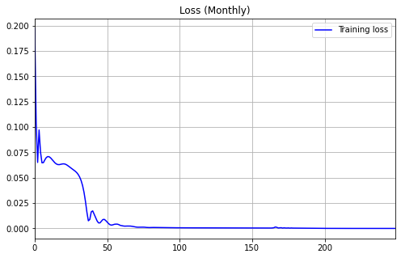

```python
# Plot and Save Loss
fig = plt.figure(figsize = (8,5))
plt.title('Loss (Monthly)')
plt.plot(hist, label="Training loss", color='b')
plt.legend()
figPath = 'figures/'
plt.grid(True)
plt.autoscale(axis='x',tight=True)
plt.show()
fig.savefig(figPath + 'loss_monthly.png', dpi = 300)
```

```python
# make predictions
y_test_pred = model(x_test)

# invert predictions - to get numpy array from tensors
y_train_pred_inv = scaler.inverse_transform(y_train_pred.detach().numpy())
y_train_inv = scaler.inverse_transform(y_train.detach().numpy())
y_test_pred_inv = scaler.inverse_transform(y_test_pred.detach().numpy())
y_test_inv = scaler.inverse_transform(y_test.detach().numpy())

# calculate root mean squared error
trainScoreM = math.sqrt(mean_squared_error(y_train_inv[:,0], y_train_pred_inv[:,0]))
print('Train Score: %.2f RMSE' % (trainScoreM))
testScoreM = math.sqrt(mean_squared_error(y_test_inv[:,0], y_test_pred_inv[:,0]))
print('Test Score: %.2f RMSE' % (testScoreM))
# calculate MAPE
testMapeM = (mape(y_test_inv[:,0], y_test_pred_inv[:,0]))
print('MAPE: %.2f MAPE' % (testMapeM))

rmse_list.append(testScoreM)
mape_list.append(testMapeM)
```

```
Train Score: 0.03 RMSE
Test Score: 1.31 RMSE
MAPE: 0.14 MAPE
```

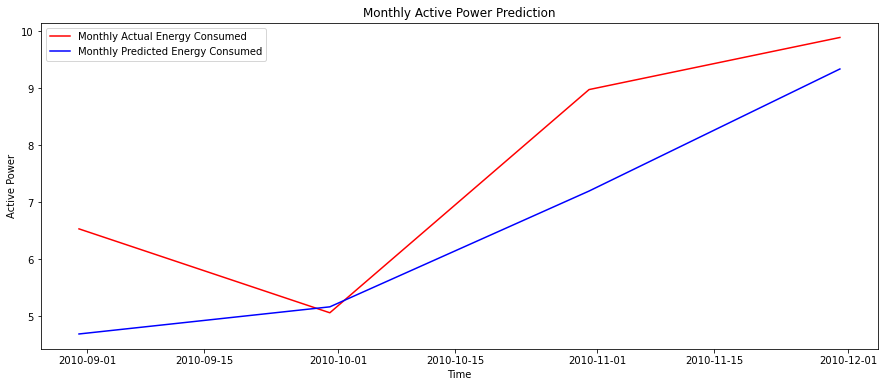

```python
# Visualising the results
figure, axes = plt.subplots(figsize=(15, 6))
axes.xaxis_date()

axes.plot(monthly_data[len(monthly_data)-len(y_test):].index, y_test_inv, color = 'red', label = 'Monthly Actual Energy Consumed')
axes.plot(monthly_data[len(monthly_data)-len(y_test):].index, y_test_pred_inv, color = 'blue', label = 'Monthly Predicted Energy Consumed')

plt.title('Monthly Active Power Prediction')
plt.xlabel('Time')
plt.ylabel('Active Power')
plt.legend()
plt.show()
figure.savefig(figPath + 'Actual vs Predicted Monthly.png', dpi = 300)
```

### Weekly Predictions

```python
weekly_te = weekly_data['active_power']
valuesW = weekly_te.values
scaler = MinMaxScaler(feature_range=(-1,1))
scaled_te = scaler.fit_transform(valuesW.reshape(-1,1))
# scaled_te
```

```python
# Data Preparation Function
training_data_len = math.ceil(len(valuesW)* 0.80)
def load_data(scaled, look_back):
    data_raw = scaled # convert to numpy array
    data = []
    # create all possible sequences of length look_back
    for index in range(len(data_raw) - look_back):
        data.append(data_raw[index: index + look_back])

    data = np.array(data);
    test_set_size = int(np.round(0.2*data.shape[0]));
    train_set_size = data.shape[0] - (test_set_size);

    x_train = data[:train_set_size,:-1,:]
    y_train = data[:train_set_size,-1,:]

    x_test = data[train_set_size:,:-1]
    y_test = data[train_set_size:,-1,:]

    return [x_train, y_train, x_test, y_test]

look_back = 30
```

```python
# Train Test Split
x_train, y_train, x_test, y_test = load_data(scaled_te, look_back)
print('x_train.shape = ',x_train.shape)
print('y_train.shape = ',y_train.shape)
print('x_test.shape = ',x_test.shape)
print('y_test.shape = ',y_test.shape)
# Converting NumPy to Tensors for torch requirement
x_train = torch.from_numpy(x_train).type(torch.Tensor)
x_test = torch.from_numpy(x_test).type(torch.Tensor)
y_train = torch.from_numpy(y_train).type(torch.Tensor)
y_test = torch.from_numpy(y_test).type(torch.Tensor)
y_train.size(),x_train.size()
```

```
x_train.shape =  (142, 29, 1)
y_train.shape =  (142, 1)
x_test.shape =  (35, 29, 1)
y_test.shape =  (35, 1)
```

```
(torch.Size([142, 1]), torch.Size([142, 29, 1]))
```

```python
# Train model
num_epochs = 200
hist = np.zeros(num_epochs)

seq_dim =look_back-1   # Number of steps to unroll

for t in range(num_epochs):
    # Forward pass
    y_train_pred = model(x_train)

    loss = loss_fn(y_train_pred, y_train)
    if t % 10 == 0 and t !=0:
        print("--------------------------------")
        print("Epoch ", t, "LOSS: ", loss.item())
    hist[t] = loss.item()

    optimiser.zero_grad() # Zero out gradient, else they will accumulate between epochs

    loss.backward() # Backward pass

    optimiser.step() # Update parameters
```

```
--------------------------------
Epoch  10 LOSS:  0.028879662975668907
--------------------------------
Epoch  20 LOSS:  0.0184012521058321
--------------------------------
Epoch  30 LOSS:  0.017017049714922905
--------------------------------
Epoch  40 LOSS:  0.016603082418441772
--------------------------------
Epoch  50 LOSS:  0.016165340319275856
--------------------------------
Epoch  60 LOSS:  0.0157259963452816
--------------------------------
Epoch  70 LOSS:  0.015270167961716652
--------------------------------
Epoch  80 LOSS:  0.014668723568320274
--------------------------------
Epoch  90 LOSS:  0.013496282510459423
--------------------------------
Epoch  100 LOSS:  0.012910669669508934
--------------------------------
Epoch  110 LOSS:  0.012663536705076694
--------------------------------
Epoch  120 LOSS:  0.012499859556555748
--------------------------------
Epoch  130 LOSS:  0.012305699288845062
--------------------------------
Epoch  140 LOSS:  0.012162263505160809
--------------------------------
Epoch  150 LOSS:  0.011989750899374485
--------------------------------
Epoch  160 LOSS:  0.011939768679440022
--------------------------------
Epoch  170 LOSS:  0.011859680525958538
--------------------------------
Epoch  180 LOSS:  0.01151562761515379
--------------------------------
Epoch  190 LOSS:  0.011319306679069996
```

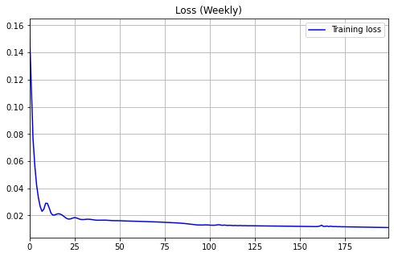

```python
fig = plt.figure(figsize = (8,5))
plt.title('Loss (Weekly)')
plt.plot(hist, label="Training loss", color='b')
plt.legend()
figPath = 'figures/'
plt.grid(True)
plt.autoscale(axis='x',tight=True)
plt.show()
fig.savefig(figPath + 'loss_weekly.png', dpi = 300)
```

```python
# make predictions
y_test_pred = model(x_test)

# invert predictions
y_train_pred_inv = scaler.inverse_transform(y_train_pred.detach().numpy())
y_train_inv = scaler.inverse_transform(y_train.detach().numpy())
y_test_pred_inv = scaler.inverse_transform(y_test_pred.detach().numpy())
y_test_inv = scaler.inverse_transform(y_test.detach().numpy())

# calculate root mean squared error
trainScoreW = math.sqrt(mean_squared_error(y_train_inv[:,0], y_train_pred_inv[:,0]))
print('Train Score: %.2f RMSE' % (trainScoreW))
testScoreW = math.sqrt(mean_squared_error(y_test_inv[:,0], y_test_pred_inv[:,0]))
print('Test Score: %.2f RMSE' % (testScoreW))
testMapeW = (mape(y_test_inv[:,0], y_test_pred_inv[:,0]))
print('MAPE: %.2f MAPE' % (testMapeW))

rmse_list.append(testScoreW)
mape_list.append(testMapeW)
```

```
Train Score: 1.40 RMSE
Test Score: 1.54 RMSE
MAPE: 0.15 MAPE
```

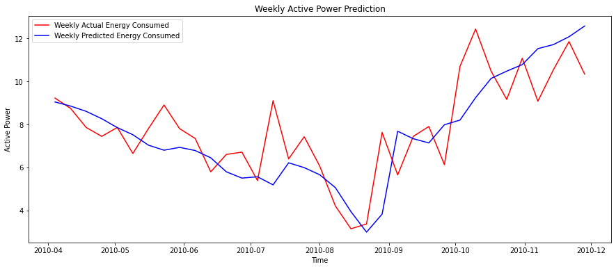

```python
# Visualising the results
figure, axes = plt.subplots(figsize=(15, 6))
axes.xaxis_date()

axes.plot(weekly_data[len(weekly_data)-len(y_test):].index, y_test_inv, color = 'red', label = 'Weekly Actual Energy Consumed')
axes.plot(weekly_data[len(weekly_data)-len(y_test):].index, y_test_pred_inv, color = 'blue', label = 'Weekly Predicted Energy Consumed')

plt.title('Weekly Active Power Prediction')
plt.xlabel('Time')
plt.ylabel('Active Power')
plt.legend()
plt.show()
figure.savefig(figPath + 'Actual vs Predicted Weekly.png', dpi = 300)
```

### Daily Predictions

```python
daily_te = daily_data['active_power']
valuesD = daily_te.values
scaler = MinMaxScaler(feature_range=(-1,1))
scaled_te = scaler.fit_transform(valuesD.reshape(-1,1))
# scaled_te
```

```python
# Data Preparation Function
training_data_len = math.ceil(len(valuesD)* 0.80)
def load_data(scaled, look_back):
    data_raw = scaled # convert to numpy array
    data = []
    # create all possible sequences of length look_back
    for index in range(len(data_raw) - look_back):
        data.append(data_raw[index: index + look_back])

    data = np.array(data);
    test_set_size = int(np.round(0.2*data.shape[0]));
    train_set_size = data.shape[0] - (test_set_size);

    x_train = data[:train_set_size,:-1,:]
    y_train = data[:train_set_size,-1,:]

    x_test = data[train_set_size:,:-1]
    y_test = data[train_set_size:,-1,:]

    return [x_train, y_train, x_test, y_test]

look_back = 30
```

```python
# Train Test Split
x_train, y_train, x_test, y_test = load_data(scaled_te, look_back)
print('x_train.shape = ',x_train.shape)
print('y_train.shape = ',y_train.shape)
print('x_test.shape = ',x_test.shape)
print('y_test.shape = ',y_test.shape)
# Converting NumPy to Tensors for torch requirement
x_train = torch.from_numpy(x_train).type(torch.Tensor)
x_test = torch.from_numpy(x_test).type(torch.Tensor)
y_train = torch.from_numpy(y_train).type(torch.Tensor)
y_test = torch.from_numpy(y_test).type(torch.Tensor)
y_train.size(),x_train.size()
```

```
x_train.shape =  (1130, 29, 1)
y_train.shape =  (1130, 1)
x_test.shape =  (282, 29, 1)
y_test.shape =  (282, 1)
```

```
(torch.Size([1130, 1]), torch.Size([1130, 29, 1]))
```

```python
# Train model
num_epochs = 200
hist = np.zeros(num_epochs)

seq_dim =look_back-1   # Number of steps to unroll

for t in range(num_epochs):
    # Forward pass
    y_train_pred = model(x_train)

    loss = loss_fn(y_train_pred, y_train)
    if t % 10 == 0 and t !=0:
        print("--------------------------------")
        print("Epoch ", t, "LOSS: ", loss.item())
    hist[t] = loss.item()

    optimiser.zero_grad() # Zero out gradient, else they will accumulate between epochs

    loss.backward() # Backward pass

    optimiser.step() # Update parameters
```

```
--------------------------------
Epoch  10 LOSS:  0.020685182884335518
--------------------------------
Epoch  20 LOSS:  0.01874525099992752
--------------------------------
Epoch  30 LOSS:  0.018245860934257507
--------------------------------
Epoch  40 LOSS:  0.017952298745512962
--------------------------------
Epoch  50 LOSS:  0.01773194968700409
--------------------------------
Epoch  60 LOSS:  0.017576642334461212
--------------------------------
Epoch  70 LOSS:  0.017477350309491158
--------------------------------
Epoch  80 LOSS:  0.01741136610507965
--------------------------------
Epoch  90 LOSS:  0.01735718362033367
--------------------------------
Epoch  100 LOSS:  0.017306610941886902
--------------------------------
Epoch  110 LOSS:  0.017255133017897606
--------------------------------
Epoch  120 LOSS:  0.017199348658323288
--------------------------------
Epoch  130 LOSS:  0.01713632233440876
--------------------------------
Epoch  140 LOSS:  0.01706385239958763
--------------------------------
Epoch  150 LOSS:  0.016981620341539383
--------------------------------
Epoch  160 LOSS:  0.01689467392861843
--------------------------------
Epoch  170 LOSS:  0.01681140437722206
--------------------------------
Epoch  180 LOSS:  0.016739558428525925
--------------------------------
Epoch  190 LOSS:  0.016851291060447693
```

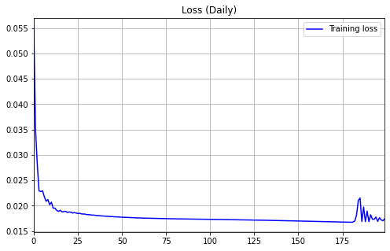

```python
fig = plt.figure(figsize = (8,5))
plt.title('Loss (Daily)')
plt.plot(hist, label="Training loss", color='b')
plt.legend()
figPath = 'figures/'
plt.grid(True)
plt.autoscale(axis='x',tight=True)
plt.show()
fig.savefig(figPath + 'loss_daily.png', dpi = 300)
```

```python
# make predictions
y_test_pred = model(x_test)

# invert predictions
y_train_pred_inv = scaler.inverse_transform(y_train_pred.detach().numpy())
y_train_inv = scaler.inverse_transform(y_train.detach().numpy())
y_test_pred_inv = scaler.inverse_transform(y_test_pred.detach().numpy())
y_test_inv = scaler.inverse_transform(y_test.detach().numpy())

# calculate root mean squared error
trainScoreD = math.sqrt(mean_squared_error(y_train_inv[:,0], y_train_pred_inv[:,0]))
print('Train Score: %.2f RMSE' % (trainScoreD))
testScoreD = math.sqrt(mean_squared_error(y_test_inv[:,0], y_test_pred_inv[:,0]))
print('Test Score: %.2f RMSE' % (testScoreD))
testMapeD = (mape(y_test_inv[:,0], y_test_pred_inv[:,0]))
print('MAPE: %.2f MAPE' % (testMapeD))

rmse_list.append(testScoreD)
mape_list.append(testMapeD)
```

```
Train Score: 2.73 RMSE
Test Score: 2.03 RMSE
MAPE: 0.18 MAPE
```

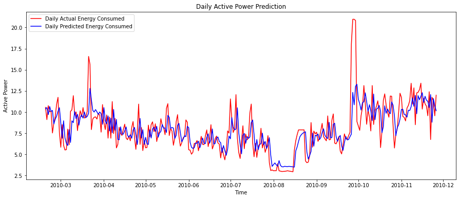

```python
# Visualising the results
figure, axes = plt.subplots(figsize=(15, 6))
axes.xaxis_date()

axes.plot(daily_data[len(daily_data)-len(y_test):].index, y_test_inv, color = 'red', label = 'Daily Actual Energy Consumed')
axes.plot(daily_data[len(daily_data)-len(y_test):].index, y_test_pred_inv, color = 'blue', label = 'Daily Predicted Energy Consumed')

plt.title('Daily Active Power Prediction')
plt.xlabel('Time')
plt.ylabel('Active Power')
plt.legend()
plt.show()
figure.savefig(figPath + 'Acutal vs Predicted Daily.png', dpi = 300)
```

### Hourly Predictions

```python
hourly_te = hourly_data['active_power']
valuesH = hourly_te.values
scaler = MinMaxScaler(feature_range=(-1,1))
scaled_te = scaler.fit_transform(valuesH.reshape(-1,1))
# scaled_te
```

```python
# Data Preparation Function
training_data_len = math.ceil(len(valuesH)* 0.80)
def load_data(scaled, look_back):
    data_raw = scaled # convert to numpy array
    data = []
    # create all possible sequences of length look_back
    for index in range(len(data_raw) - look_back):
        data.append(data_raw[index: index + look_back])

    data = np.array(data);
    test_set_size = int(np.round(0.2*data.shape[0]));
    train_set_size = data.shape[0] - (test_set_size);

    x_train = data[:train_set_size,:-1,:]
    y_train = data[:train_set_size,-1,:]

    x_test = data[train_set_size:,:-1]
    y_test = data[train_set_size:,-1,:]

    return [x_train, y_train, x_test, y_test]

look_back = 30
```

```python
# Train Test Split
x_train, y_train, x_test, y_test = load_data(scaled_te, look_back)
print('x_train.shape = ',x_train.shape)
print('y_train.shape = ',y_train.shape)
print('x_test.shape = ',x_test.shape)
print('y_test.shape = ',y_test.shape)
# Converting NumPy to Tensors for torch requirement
x_train = torch.from_numpy(x_train).type(torch.Tensor)
x_test = torch.from_numpy(x_test).type(torch.Tensor)
y_train = torch.from_numpy(y_train).type(torch.Tensor)
y_test = torch.from_numpy(y_test).type(torch.Tensor)
y_train.size(),x_train.size()
```

```
x_train.shape =  (27647, 29, 1)
y_train.shape =  (27647, 1)
x_test.shape =  (6912, 29, 1)
y_test.shape =  (6912, 1)
```

```
(torch.Size([27647, 1]), torch.Size([27647, 29, 1]))
```

```python
# Train model
num_epochs = 70
hist = np.zeros(num_epochs)

seq_dim =look_back-1   # Number of steps to unroll

for t in range(num_epochs):
    # Forward pass
    y_train_pred = model(x_train)

    loss = loss_fn(y_train_pred, y_train)
    if t % 10 == 0 and t !=0:
        print("--------------------------------")
        print("Epoch ", t, "LOSS: ", loss.item())
    hist[t] = loss.item()

    optimiser.zero_grad() # Zero out gradient, else they will accumulate between epochs

    loss.backward() # Backward pass

    optimiser.step() # Update parameters
```

```
--------------------------------
Epoch  10 LOSS:  0.0331006795167923
--------------------------------
Epoch  20 LOSS:  0.03047063574194908
--------------------------------
Epoch  30 LOSS:  0.029585128650069237
--------------------------------
Epoch  40 LOSS:  0.029169227927923203
--------------------------------
Epoch  50 LOSS:  0.02894008159637451
--------------------------------
Epoch  60 LOSS:  0.028752822428941727
```

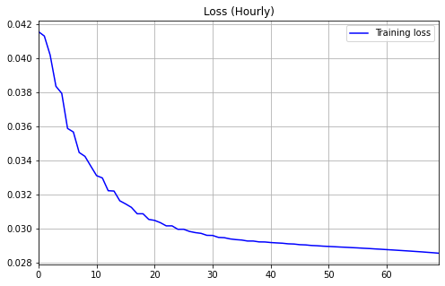

```python
fig = plt.figure(figsize = (8,5))
plt.title('Loss (Hourly)')
plt.plot(hist, label="Training loss", color='b')
plt.legend()
figPath = 'figures/'
plt.grid(True)
plt.autoscale(axis='x',tight=True)
plt.show()
fig.savefig(figPath + 'loss_hourly.png', dpi = 300)
```

```python
# make predictions
y_test_pred = model(x_test)

# invert predictions
y_train_pred_inv = scaler.inverse_transform(y_train_pred.detach().numpy())
y_train_inv = scaler.inverse_transform(y_train.detach().numpy())
y_test_pred_inv = scaler.inverse_transform(y_test_pred.detach().numpy())
y_test_inv = scaler.inverse_transform(y_test.detach().numpy())

# calculate root mean squared error
trainScoreH = math.sqrt(mean_squared_error(y_train_inv[:,0], y_train_pred_inv[:,0]))
print('Train Score: %.2f RMSE' % (trainScoreH))
testScoreH = math.sqrt(mean_squared_error(y_test_inv[:,0], y_test_pred_inv[:,0]))
print('Test Score: %.2f RMSE' % (testScoreH))
testMapeH = (mape(y_test_inv[:,0], y_test_pred_inv[:,0]))
print('MAPE: %.2f MAPE' % (testMapeH))

rmse_list.append(testScoreH)
mape_list.append(testMapeH)
```

```
Train Score: 5.36 RMSE
Test Score: 3.96 RMSE
MAPE: 0.37 MAPE
```

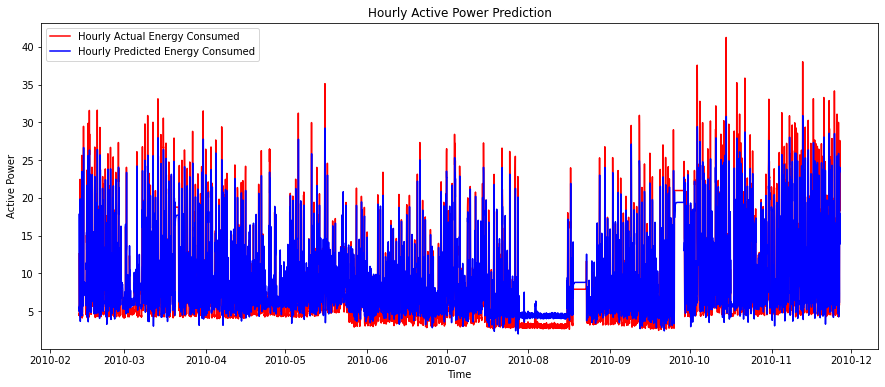

```python
# Visualising the results
figure, axes = plt.subplots(figsize=(15, 6))
axes.xaxis_date()

axes.plot(hourly_data[len(hourly_data)-len(y_test):].index, y_test_inv, color = 'red', label = 'Hourly Actual Energy Consumed')
axes.plot(hourly_data[len(hourly_data)-len(y_test):].index, y_test_pred_inv, color = 'blue', label = 'Hourly Predicted Energy Consumed')

plt.title('Hourly Active Power Prediction')
plt.xlabel('Time')
plt.ylabel('Active Power')
plt.legend()
plt.show()
figure.savefig(figPath + 'Actual vs Predicted Hourly .png', dpi = 300)
```

### 7. Results

```python
# Dictionary to convert into DataFrame
res_dict = {'MAPE': mape_list, 'RMSE': rmse_list}
```

```python
# DataFrame of Results
results = pd.DataFrame(res_dict,index=['Monthly','Weekly','Daily','Hourly'])
results
```

|  | MAPE | RMSE |
| --- | --- | --- |
| Monthly | 0.139332 | 1.312295 |
| Weekly | 0.148594 | 1.540464 |
| Daily | 0.181076 | 2.029960 |
| Hourly | 0.374480 | 3.957490 |

### 8. Conclusion and Future Scope

#### Conclusion:

- From the above table of result metrics, it can be said that the most efficient time instance to predict the values is Monthly instance as we got less MAPE of 13% and RMSE as compared to other time instances. Even if 1.25% of data was missing, model was able to perform well. If the values were not missing, model performance would have been more better than the current.
- The best time instances after monthly instance are weekly and daily. For daily instance, results are pretty good as we got MAPE 18%. This means if the model were able to forecast in future, it will only forecast 18 values incorrectly, giving 82 correct values which is acceptable.
- It is observed that for the tightly coupled data such as for hourly instance, model takes time for computation and hence for 70 epochs, MAPE was around 37 %. If epochs are increased till appropriate amount, there is a chance to get a lower value of MAPE.

#### Future Scope:

- For this task, only single variate LSTM was used taking only timestamp/ timeseries as input and predicting the output/ target variable. For the same task, multivariate LSTM could be used to forecast the target variable taking more than one input features.
- If the high computational devices are available, model could be trained at instance of seconds and with the help of proper hyperparameter tuning, most accurate results could be obtained.

### 9. References and Citations

- https://archive.ics.uci.edu/ml/datasets/Individual+household+electric+power+consumption
- https://pytorch.org/docs/stable/generated/torch.nn.LSTM.html
- https://pytorch.org/tutorials/beginner/nlp/sequence_models_tutorial.html
- https://en.wikipedia.org/wiki/Recurrent_neural_network
- https://en.wikipedia.org/wiki/Long_short-term_memory
- https://www.predicthq.com/events/lstm-time-series-forecasting
- https://medium.com/@kangeugine/long-short-term-memory-lstm-concept-cb3283934359